# Berlin CO2 Leistungsbild

Bhaskar Kamble

15 August 2019

# Teil 2.

```r
source("D:/GITHUB_REPOS/co2emissions/Berlin/BezirkAnalysis/mainScriptCO2Emissions_v2.R")
source("D:/GITHUB_REPOS/co2emissions/Berlin/BezirkAnalysis/getCumSums.R")
```

```r
require(ggplot2)
#look at line 187 of BerlinPresentationCO2BalanceUnified_v6.Rmd
points_line_lm <- function(input_data,
                           xVar,
                           yVar,
                           ymin,
                           ymax,
                           x_eq=2008,
                           y_eq=2500,
                           size_eq=6,
                           plot_title,
                           xlab,
                           ylab,
                           slope_round_to = 2,
                           intercept_round_to = 0) {
  linmod <- lm(data=input_data , formula = get(yVar)~get(xVar))
  coeff_a <- as.numeric(coefficients(linmod)[1])
  coeff_b <- as.numeric(coefficients(linmod)[2])
  if (coeff_a<0) {
    sign_coeff_a <- " "
  } else {sign_coeff_a <- "+"}


  b_round <- as.character(round(coeff_b,slope_round_to))
  a_round <- as.character(round(coeff_a,intercept_round_to))
  lm_equation <- paste0( b_round , "x" , sign_coeff_a ,  a_round)

  g <- ggplot() + geom_line(data=input_data , aes(x=get(xVar) , y=get(yVar)) , color="blue"
  )+geom_point(data=input_data , aes(x=get(xVar) , y=get(yVar)) , color="blue"
  )+geom_smooth(method="lm" , data=input_data , aes(x=get(xVar) , y=get(yVar)) , se=FALSE
  )+annotate(geom="text" , label=lm_equation , x = x_eq , y = y_eq , size=size_eq
  )+ylim(ymin,ymax)+scale_x_continuous(breaks=seq(2002,2018,2)
  )+theme_bw()+labs(x=xlab,
  y=ylab,title=plot_title)
  return(g)
}
```

```r
require(ggplot2)
col_list <- c("royalblue4","orangered1","gray59","orange","blue","olivedrab4")
cols <- c(
          "erdgas"      = "royalblue4",
          "waerme"      = "orangered1",
          "fluessiggas" = "gray59",
          "heizoel"     = "orange",
          "holzpellets" = "blue",
          "strom"       = "olivedrab4"
          )
plot_title <- NULL
order_legend <- rev(c("erdgas","waerme","fluessiggas","heizoel","holzpellets","strom"))
order_labels <- rev(c("Erdgas","Wärme (N+F)","Flüssiggas","Heizöl","Holzpellets","Strom (D+WP)"))
et_list <- c("erdgas","waerme","fluessiggas","heizoel","holzpellets","strom")
plot_byET <- function(obj,xlabel,ylabel,plottitle) {
  ggplot()+geom_line(data=obj,aes(x=abrechnungsjahr,y=get(et_list[1]),color=et_list[1]),size=5
  )+geom_line(data=obj,aes(x=abrechnungsjahr,y=get(et_list[2]),color=et_list[2])
  )+geom_line(data=obj,aes(x=abrechnungsjahr,y=get(et_list[3]),color=et_list[3])
  )+geom_line(data=obj,aes(x=abrechnungsjahr,y=get(et_list[4]),color=et_list[4])
  )+geom_line(data=obj,aes(x=abrechnungsjahr,y=get(et_list[5]),color=et_list[5])
  )+geom_line(data=obj,aes(x=abrechnungsjahr,y=get(et_list[6]),color=et_list[6])
  )+scale_color_manual(labels=order_labels,name=" ",values=cols,breaks=order_legend
  )+geom_ribbon(data=obj,aes(x=abrechnungsjahr,ymin=0,ymax=get(et_list[6])),fill=col_list[6]
  )+geom_ribbon(data=obj,aes(x=abrechnungsjahr,ymin=0,ymax=get(et_list[5])),fill=col_list[5]
  )+geom_ribbon(data=obj,aes(x=abrechnungsjahr,ymin=0,ymax=get(et_list[4])),fill=col_list[4]
  )+geom_ribbon(data=obj,aes(x=abrechnungsjahr,ymin=0,ymax=get(et_list[3])),fill=col_list[3]
  )+geom_ribbon(data=obj,aes(x=abrechnungsjahr,ymin=0,ymax=get(et_list[2])),fill=col_list[2]
  )+geom_ribbon(data=obj,aes(x=abrechnungsjahr,ymin=0,ymax=get(et_list[1])),fill=col_list[1])+theme_bw()+ labs(x=xlabel,y=ylabel,title=plottitle) + theme(plot.title=element_text(size=30), axis.title.x=element_text(size=20, face="bold"), axis.title.y=element_text(size=20, face="bold"), legend.text = element_text(size=15), axis.text.x=element_text(size=15,face="bold"), axis.text.y=element_text(size=15,face="bold"), legend.key.size=unit(2, "lines")
  )+scale_x_continuous(breaks=seq(2002,2018,2))
}
```

```r
extract_co2_emission <- function(obj_sfh , obj_mfh) {
  co2_SFH <- obj_sfh$co2_emissions
  co2_MFH <- obj_mfh$co2_emissions
  co2_SFH$strom[co2_SFH$abrechnungsjahr < 2010] <- mean(co2_SFH$strom[co2_SFH$abrechnungsjahr >2009])
  co2_MFH$strom[co2_MFH$abrechnungsjahr < 2010] <- mean(co2_MFH$strom[co2_MFH$abrechnungsjahr >2009])
  #recalculate "total" column
  co2_SFH <- getRowSums(co2_SFH[,names(co2_SFH)!="total"] , dropCols = "abrechnungsjahr")
  co2_MFH <- getRowSums(co2_MFH[,names(co2_MFH)!="total"] , dropCols = "abrechnungsjahr")
  #---
  co2_ALL <- co2_SFH + co2_MFH
  co2_ALL$abrechnungsjahr <- 2002:2018
  co2_SFH <- co2_SFH/1e7
  co2_MFH <- co2_MFH/1e7
  co2_ALL <- co2_ALL/1e7
  co2_SFH$abrechnungsjahr <- 2002:2018
  co2_MFH$abrechnungsjahr <- 2002:2018
  co2_ALL$abrechnungsjahr <- 2002:2018

  return_data <- list()
  return_data$SFH <- co2_SFH
  return_data$MFH <- co2_MFH
  return_data$ALL <- co2_ALL
  return(return_data)
}

extract_aes <- function(obj_sfh , obj_mfh) {
  aes_SFH <- obj_sfh$energy_shares_absolute
  aes_MFH <- obj_mfh$energy_shares_absolute
  aes_SFH$strom[aes_SFH$abrechnungsjahr < 2010] <- mean(aes_SFH$strom[aes_SFH$abrechnungsjahr >2009])
  aes_MFH$strom[aes_MFH$abrechnungsjahr < 2010] <- mean(aes_MFH$strom[aes_MFH$abrechnungsjahr >2009])
  aes_SFH <- getRowSums(aes_SFH , dropCols = "abrechnungsjahr")
  aes_MFH <- getRowSums(aes_MFH , dropCols = "abrechnungsjahr")
  aes_ALL <- aes_SFH + aes_MFH
  aes_ALL$abrechnungsjahr <- 2002:2018

  return_data <- list()
  return_data$SFH <- aes_SFH
  return_data$MFH <- aes_MFH
  return_data$ALL <- aes_ALL
  return(return_data)
}
```

```r
bezirk_proper_names  <- c(
  "Charlottenburg-Wilmersdorf",
  "Friedrichshain-Kreuzberg",
  "Lichtenberg",
  "Marzahn-Hellersdorf",
  "Mitte",
  "Neukölln",
  "Pankow"    ,
  "Reinickendorf",
  "Spandau",
  "Steglitz-Zehlendorf" ,
  "Tempelhof-Schöneberg",
  "Treptow-Köpenick"
)

bezirk_list  <- c(
  "charlottenburg_wilmersdorf",
  "friedrichshain_kreuzberg",
  "lichtenberg",
  "marzahn_hellersdorf",
  "mitte",
  "neukoelln",
  "pankow"    ,
  "reinickendorf",
  "spandau",
  "steglitz_zehlendorf" ,
  "tempelhof_schoeneberg",
  "treptow_koepenick"
)
```

```r
i_bezirk <- 0
i_section <- 6
```

```r
i_bezirk           <- i_bezirk + 1
bezirk             <- bezirk_list[i_bezirk]
bezirk_proper_name <- bezirk_proper_names[i_bezirk]
et_list <- c("erdgas","waerme","fluessiggas","heizoel","holzpellets","strom")
```

```r
i_section <- i_section + 1
i_subsection <- 0
i_subsubsection <- 0
```

# Charlottenburg-Wilmersdorf

# 7.Charlottenburg-Wilmersdorf, alle Wohngebäude, CO2-Emission aus Beheizung 2002 – 2018

```r
i_subsection <- i_subsection + 1
```

## 7.1 Absolute Zahlen

```r
i_subsubsection <- i_subsubsection + 1
```

### 7.1.1, alle Wohngebäude, CO2-Emission aus Beheizung 2002 - 2018 in units

```r
return_SFH <- main_function("SFH" , bezirk , et_list)
return_MFH <- main_function("MFH" , bezirk , et_list)
return_co2 <- extract_co2_emission(return_SFH , return_MFH)
```

Here you need just the total co2 emitted, not split by ET.

```r
bezirk_co2_all <- return_co2$ALL
```

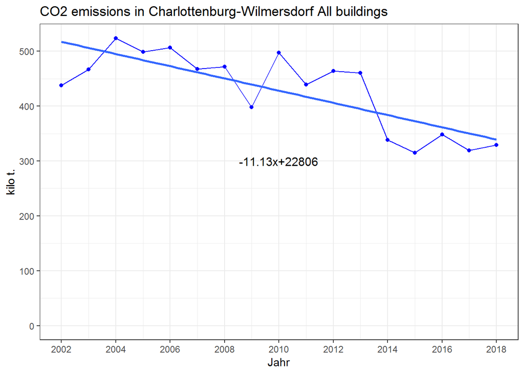

```r
points_line_lm(input_data = bezirk_co2_all,
               xVar = "abrechnungsjahr",
               yVar = "total",
               ymin = 0,
               ymax = max(bezirk_co2_all$total),
               x_eq = 2010,
               y_eq = 300,
               size_eq = 4,
               plot_title = paste0("CO2 emissions in ",bezirk_proper_name, " All buildings"),
               xlab = "Jahr",
               ylab = "kilo t.")
```

```r
i_subsubsection <- i_subsubsection + 1
```

### 7.1.2, alle Wohngebäude, CO2-Emission aus Beheizung 2002 - 2018 nach Energieträgern, Anteile in units CO2, summiert

Here you need to split by ET

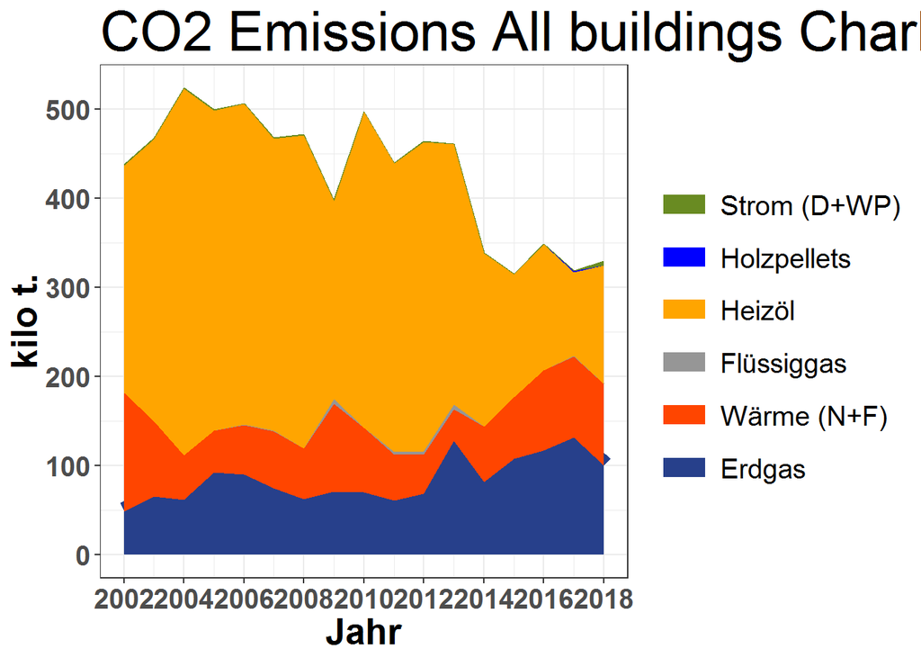

```r
bezirk_co2_all_cumsums <- getCumSums(bezirk_co2_all , dropCols = c("abrechnungsjahr","total"))
plot_byET(bezirk_co2_all_cumsums , xlabel = "Jahr" , ylabel = "kilo t." , plottitle = paste0("CO2 Emissions All buildings ",bezirk_proper_name) )
```

```r
i_subsubsection <- i_subsubsection + 1
```

### 7.1.3, alle Wohngebäude, Emission aus Beheizung 2002 - 2018 nach Energieträgern, Anteile in %

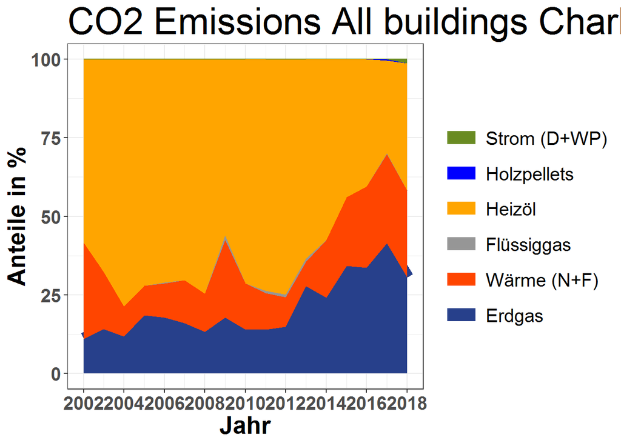

```r
bezirk_co2_all_prop <- find_proportions(bezirk_co2_all,drop_cols = c("abrechnungsjahr","total"))
bezirk_co2_all_prop_cumsums <- getCumSums(bezirk_co2_all_prop,dropCols="abrechnungsjahr")
plot_byET(bezirk_co2_all_prop_cumsums , xlabel = "Jahr" , ylabel = "Anteile in %" , plottitle = paste0("CO2 Emissions All buildings ",bezirk_proper_name) )
```

```r
i_subsection <- i_subsection + 1
i_subsubsection <- 0
```

## 7.2. Flächenbezug

```r
i_subsubsection <- i_subsubsection + 1
```

### 7.2.1. alle Wohngebäude, flächenbezogene Emission aus Beheizung 2002 - 2018

```r
bezirk_total_area <- return_SFH$totalArea
bezirk_total_area$areaALL <- bezirk_total_area$areaSFH + bezirk_total_area$areaMFH
bezirk_total_area <- 100*bezirk_total_area
bezirk_total_area$abrechnungsjahr <- 2002:2018
```

```r
bezirk_spzco2_all <- data.frame(abrechnungsjahr=2002:2018 ,   spzco2 = 1e6*(bezirk_co2_all$total / bezirk_total_area$areaALL) )
bezirk_spzco2_all
```

```
##    abrechnungsjahr   spzco2
## 1             2002 33.57633
## 2             2003 35.63707
## 3             2004 39.83281
## 4             2005 37.76728
## 5             2006 38.14932
## 6             2007 35.04844
## 7             2008 35.20240
## 8             2009 29.56346
## 9             2010 36.70257
## 10            2011 32.32556
## 11            2012 34.03863
## 12            2013 33.67363
## 13            2014 24.59735
## 14            2015 22.80240
## 15            2016 25.07753
## 16            2017 22.81435
## 17            2018 23.49628
```

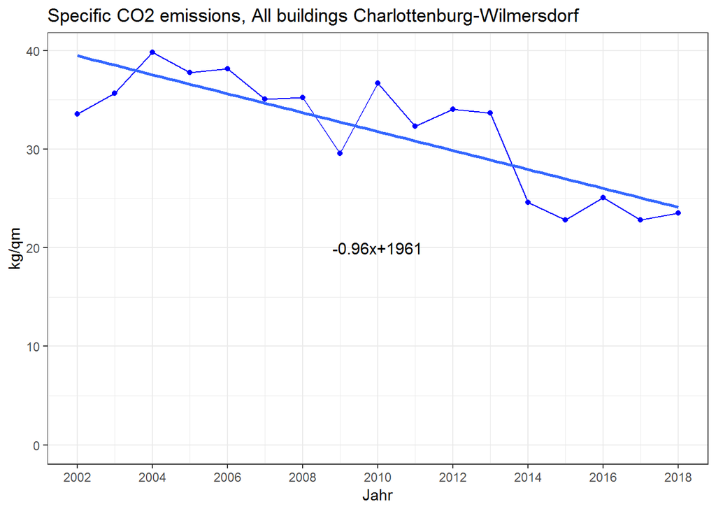

```r
points_line_lm(input_data = bezirk_spzco2_all,
               xVar = "abrechnungsjahr",
               yVar = "spzco2",
               ymin=0,
               ymax=max(bezirk_spzco2_all$spzco2),
               x_eq = 2010,
               y_eq = 20,
               size_eq = 4,
               plot_title = paste0("Specific CO2 emissions, All buildings ",bezirk_proper_name),
               xlab = "Jahr",
               ylab = "kg/qm")
```

Isn’t it strange that the above graph has almost exactly the same shape as total co2 emissions?

```r
i_subsubsection <- i_subsubsection + 1
```

### 7.2.2. alle Wohngebäude, flächenbezogene CO2-Emssion und beheizte Wohnfläche 2002 – 2018

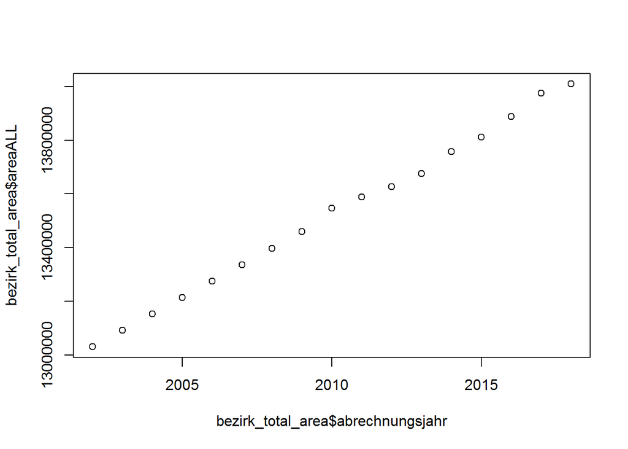

```r
plot(bezirk_total_area$abrechnungsjahr , bezirk_total_area$areaALL)
```

```r
i_subsection <- i_subsection + 1
i_subsubsection <- 0
```

## 7.3. Emission pro Einwohner

```r
i_subsubsection <- i_subsubsection + 1
```

### 7.3.1. alle Wohngebäude, CO2-Emission aus der Beheizung von Wohnraum pro Einwohner 2002 - 2018

- Need data for this.

```r
i_subsection <- i_subsection + 1
i_subsubsection <- 0
```

## 7.4. Prognose

```r
i_subsubsection <- i_subsubsection + 1
```

### 7.4.1. Alle Stadtbezirke, Prognose der CO2-Emission aus Behei¬zung von 1-2 Familiengebäuden 2019 - 2030 in Mio. t (Trend Polynom 2. Grades)

**Are you sure this is for Alle Stadtbezirke?**

```r
i_subsection <- i_subsection + 1
i_subsubsection <- 0
```

## 7.5. Einflussfaktoren

```r
i_subsubsection <- i_subsubsection + 1
```

### 7.5.1. alle Wohngebäude, Einfluss der Änderung der beheizten Flächen, des flächenbezogenen Heizenergieverbrauchs, des Energieträgerwechsels und der Dekarbonisierung auf die CO2-Emission

```r
i_subsubsection <- i_subsubsection + 1
```

### 7.5.2. alle Wohngebäude, Veränderung der flächenbezogenen CO2-Emission aus Beheizung zwischen 2012 und 2018

```r
i_subsubsection <- i_subsubsection + 1
```

### 7.5.3. alle Wohngebäude, Emissionsintensität der Beheizung von Wohnraum 2002 – 2018 in kg CO2 - Emission je kWh Heizenergieverbrauch

```r
i_subsubsection <- i_subsubsection + 1
```

### 7.5.4. alle Wohngebäude, CO2-Emission neu errichteter Gebäude, Vergleich der Baujahre 1990 – 2001 (WSchV) und 2002 – 2018 (EnEV)

```r
i_section <- i_section + 1
i_subsection <- 0
i_subsubsection <- 0
```

# 8.Charlottenburg-Wilmersdorf, 1-2 Familiengebäude, CO2-Emission aus Beheizung 2002 – 2018

```r
i_subsection <- i_subsection + 1
```

## 8.1 Absolute Zahlen

```r
i_subsubsection <- i_subsubsection + 1
```

### 8.1.1, 1-2 Familiengebäude, CO2-Emission aus Beheizung 2002 - 2018 in units

Here you need just the total co2 emitted, not split by ET.

```r
bezirk_co2_sfh <- return_co2$SFH
```

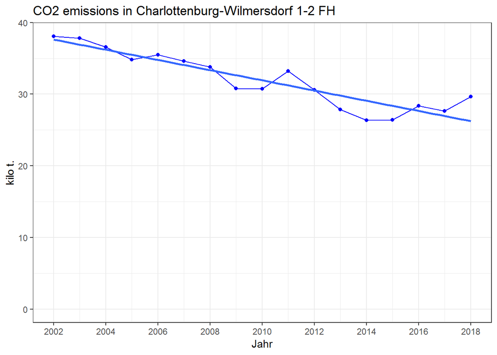

```r
points_line_lm(input_data = bezirk_co2_sfh,
               xVar = "abrechnungsjahr",
               yVar = "total",
               ymin = 0,
               ymax = max(bezirk_co2_sfh$total),
               x_eq = 2010,
               y_eq = 300,
               size_eq = 4,
               plot_title = paste0("CO2 emissions in ",bezirk_proper_name, " 1-2 FH"),
               xlab = "Jahr",
               ylab = "kilo t.")
```

```r
i_subsubsection <- i_subsubsection + 1
```

### 8.1.2, 1-2 Familiengebäude, CO2-Emission aus Beheizung 2002 - 2018 nach Energieträgern, Anteile in units CO2, summiert

Here you need to split by ET

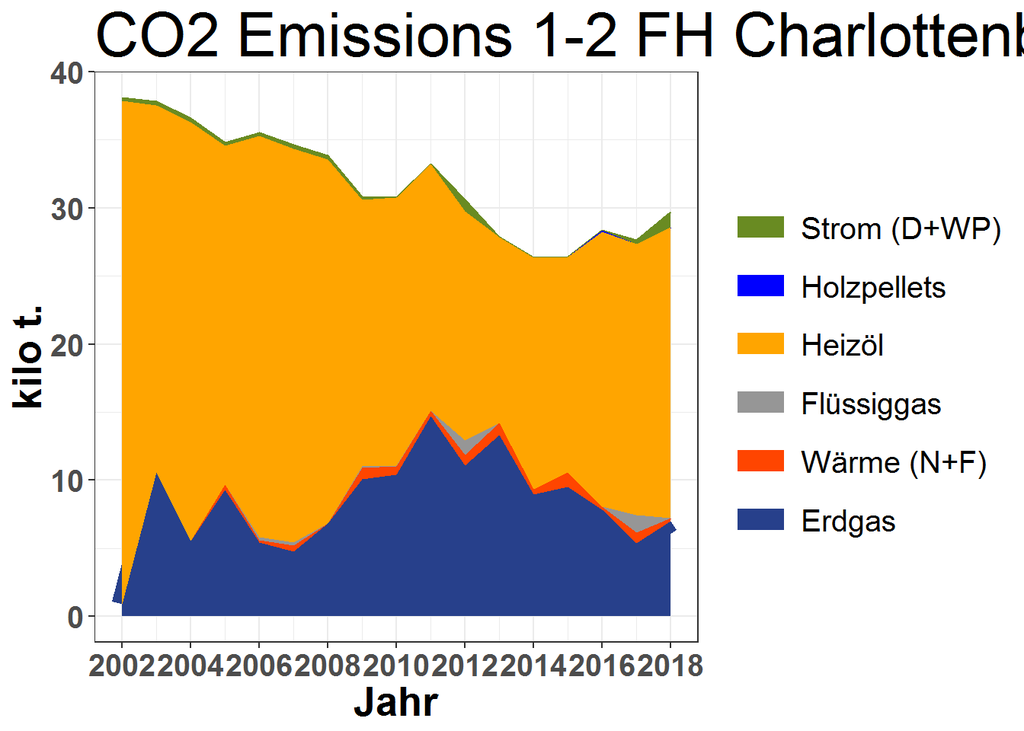

```r
bezirk_co2_sfh_cumsums <- getCumSums(bezirk_co2_sfh , dropCols = c("abrechnungsjahr","total"))
plot_byET(bezirk_co2_sfh_cumsums , xlabel = "Jahr" , ylabel = "kilo t." , plottitle = paste0("CO2 Emissions 1-2 FH ",bezirk_proper_name) )
```

```r
i_subsubsection <- i_subsubsection + 1
```

### 8.1.3, 1-2 FH, Emission aus Beheizung 2002 - 2018 nach Energieträgern, Anteile in %

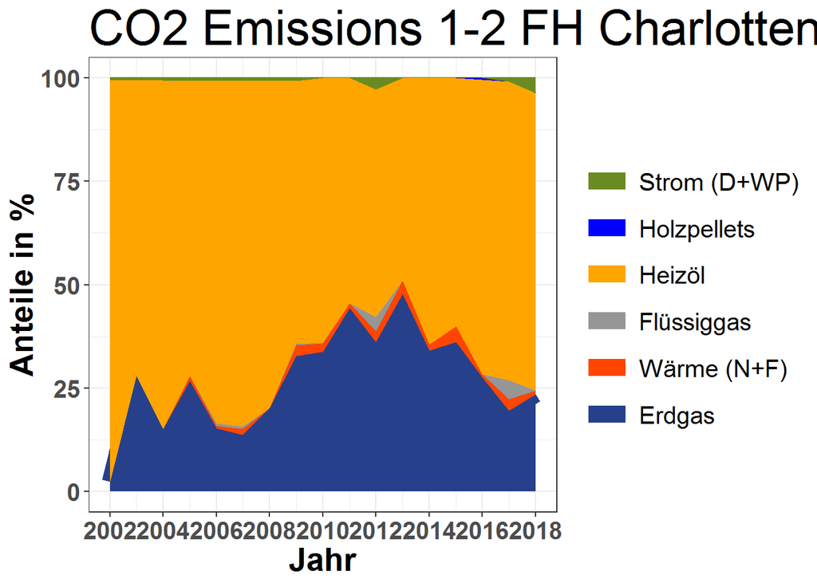

```r
bezirk_co2_sfh_prop <- find_proportions(bezirk_co2_sfh,drop_cols = c("abrechnungsjahr","total"))
bezirk_co2_sfh_prop_cumsums <- getCumSums(bezirk_co2_sfh_prop,dropCols="abrechnungsjahr")
plot_byET(bezirk_co2_sfh_prop_cumsums , xlabel = "Jahr" , ylabel = "Anteile in %" , plottitle = paste0("CO2 Emissions 1-2 FH ",bezirk_proper_name) )
```

```r
i_subsection <- i_subsection + 1
i_subsubsection <- 0
```

## 8.2. Flächenbezug

```r
i_subsubsection <- i_subsubsection + 1
```

### 8.2.1. 1-2 FH, flächenbezogene Emission aus Beheizung 2002 - 2018

```r
bezirk_spzco2_sfh <- data.frame(abrechnungsjahr=2002:2018 ,   spzco2 = 1e6*(bezirk_co2_sfh$total / bezirk_total_area$areaSFH) )
bezirk_spzco2_sfh
```

```
##    abrechnungsjahr   spzco2
## 1             2002 52.58175
## 2             2003 51.57206
## 3             2004 49.29530
## 4             2005 46.40828
## 5             2006 46.82426
## 6             2007 45.12551
## 7             2008 43.59970
## 8             2009 39.30350
## 9             2010 38.95901
## 10            2011 41.52693
## 11            2012 37.91166
## 12            2013 33.94032
## 13            2014 31.61044
## 14            2015 31.47490
## 15            2016 33.74224
## 16            2017 32.61197
## 17            2018 34.48886
```

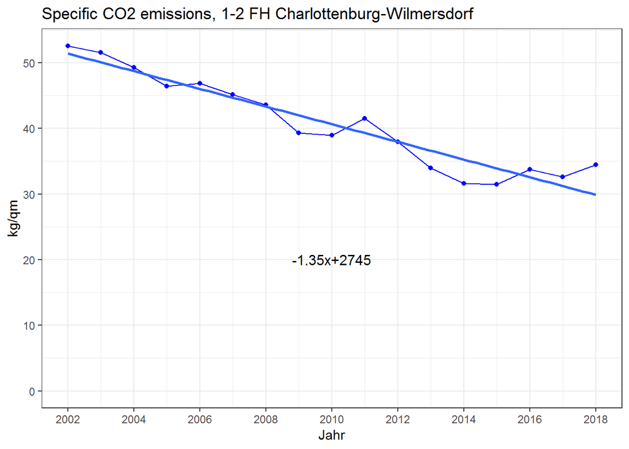

```r
points_line_lm(input_data = bezirk_spzco2_sfh,
               xVar = "abrechnungsjahr",
               yVar = "spzco2",
               ymin=0,
               ymax=max(bezirk_spzco2_sfh$spzco2),
               x_eq = 2010,
               y_eq = 20,
               size_eq = 4,
               plot_title = paste0("Specific CO2 emissions, 1-2 FH ",bezirk_proper_name),
               xlab = "Jahr",
               ylab = "kg/qm")
```

Isn’t it strange that the above graph has almost exactly the same shape as total co2 emissions?

```r
i_subsubsection <- i_subsubsection + 1
```

### 8.2.2. 1-2 FH, flächenbezogene CO2-Emssion und beheizte Wohnfläche 2002 – 2018

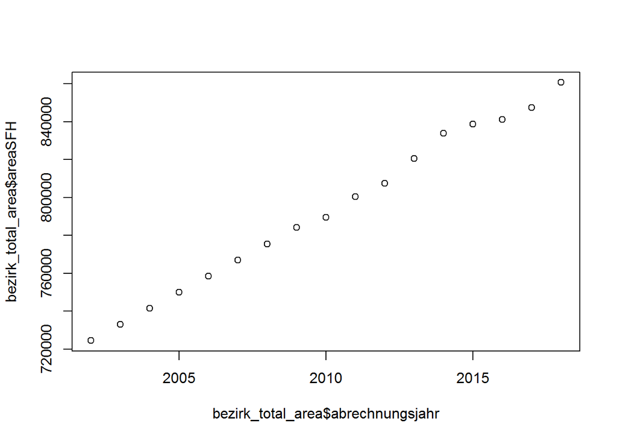

```r
plot(bezirk_total_area$abrechnungsjahr , bezirk_total_area$areaSFH)
```

```r
i_subsection <- i_subsection + 1
i_subsubsection <- 0
```

## 8.3. Emission pro Einwohner

```r
i_subsubsection <- i_subsubsection + 1
```

### 8.3.1. 1-2 FH, CO2-Emission aus der Beheizung von Wohnraum pro Einwohner 2002 - 2018

- Need data for this.

```r
i_subsection <- i_subsection + 1
i_subsubsection <- 0
```

## 8.4. Prognose

```r
i_subsubsection <- i_subsubsection + 1
```

### 8.4.1. Prognose der CO2-Emission aus Behei¬zung von 1-2 Familiengebäuden 2019 - 2030 in Mio. t (Trend Polynom 2. Grades)

```r
i_subsection <- i_subsection + 1
i_subsubsection <- 0
```

## 8.5. Einflussfaktoren

```r
i_subsubsection <- i_subsubsection + 1
```

### 8.5.1. 1-2 FH, Einfluss der Änderung der beheizten Flächen, des flächenbezogenen Heizenergieverbrauchs, des Energieträgerwechsels und der Dekarbonisierung auf die CO2-Emission

```r
i_subsubsection <- i_subsubsection + 1
```

### 8.5.2. 1-2 FH, Veränderung der flächenbezogenen CO2-Emission aus Beheizung zwischen 2012 und 2018

```r
i_subsubsection <- i_subsubsection + 1
```

### 8.5.3. 1-2 FH, Emissionsintensität der Beheizung von Wohnraum 2002 – 2018 in kg CO2 - Emission je kWh Heizenergieverbrauch

```r
i_subsubsection <- i_subsubsection + 1
```

### 8.5.4. 1-2 FH, CO2-Emission neu errichteter Gebäude, Vergleich der Baujahre 1990 – 2001 (WSchV) und 2002 – 2018 (EnEV)

```r
i_section <- i_section + 1
i_subsection <- 0
i_subsubsection <- 0
```

# 9.Charlottenburg-Wilmersdorf, Mehrfamiliengebäude, CO2-Emission aus Beheizung 2002 – 2018

```r
i_subsection <- i_subsection + 1
```

## 9.1 Absolute Zahlen

```r
i_subsubsection <- i_subsubsection + 1
```

### 9.1.1, Mehrfamiliengebäude, CO2-Emission aus Beheizung 2002 - 2018 in units

Here you need just the total co2 emitted, not split by ET.

```r
bezirk_co2_mfh <- return_co2$MFH
```

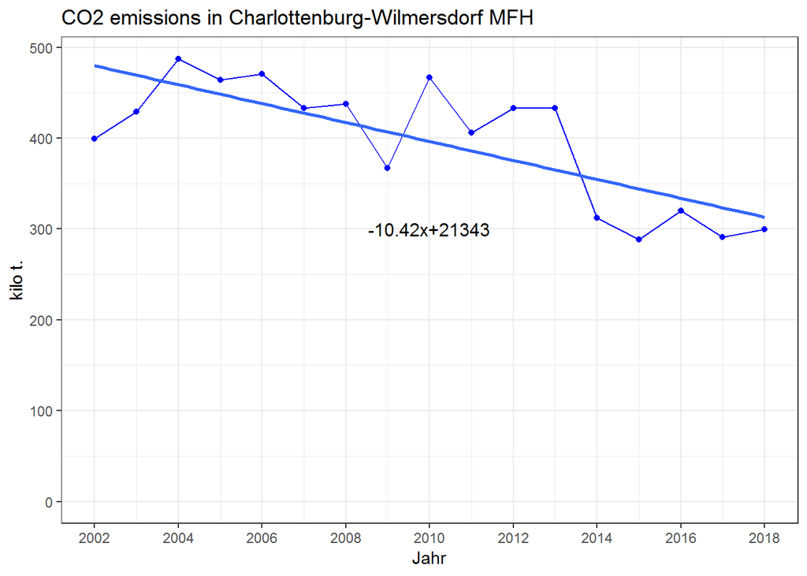

```r
points_line_lm(input_data = bezirk_co2_mfh,
               xVar = "abrechnungsjahr",
               yVar = "total",
               ymin = 0,
               ymax = max(bezirk_co2_mfh$total),
               x_eq = 2010,
               y_eq = 300,
               size_eq = 4,
               plot_title = paste0("CO2 emissions in ",bezirk_proper_name, " MFH"),
               xlab = "Jahr",
               ylab = "kilo t.")
```

```r
i_subsubsection <- i_subsubsection + 1
```

### 9.1.2, Mehrfamiliengebäude, CO2-Emission aus Beheizung 2002 - 2018 nach Energieträgern, Anteile in units CO2, summiert

Here you need to split by ET

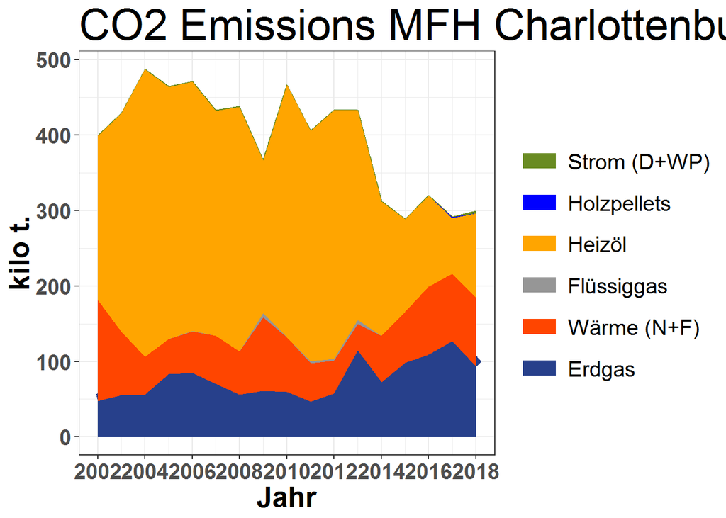

```r
bezirk_co2_mfh_cumsums <- getCumSums(bezirk_co2_mfh , dropCols = c("abrechnungsjahr","total"))
plot_byET(bezirk_co2_mfh_cumsums , xlabel = "Jahr" , ylabel = "kilo t." , plottitle = paste0("CO2 Emissions MFH ",bezirk_proper_name) )
```

```r
i_subsubsection <- i_subsubsection + 1
```

### 9.1.3, MFH, Emission aus Beheizung 2002 - 2018 nach Energieträgern, Anteile in %

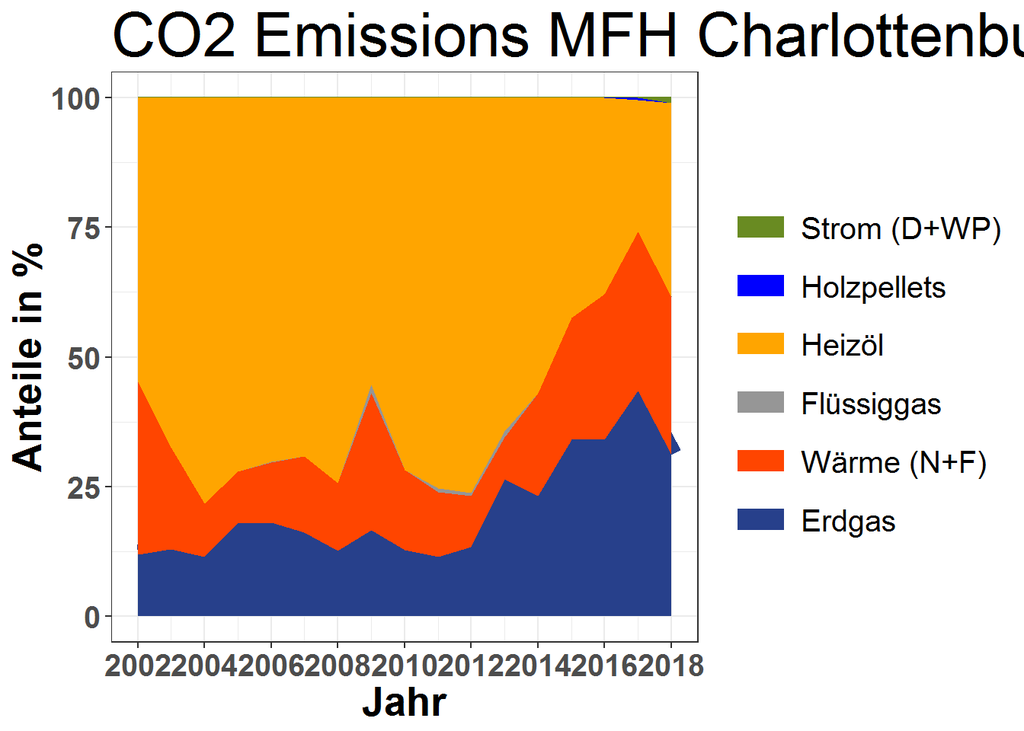

```r
bezirk_co2_mfh_prop <- find_proportions(bezirk_co2_mfh,drop_cols = c("abrechnungsjahr","total"))
bezirk_co2_mfh_prop_cumsums <- getCumSums(bezirk_co2_mfh_prop,dropCols="abrechnungsjahr")
plot_byET(bezirk_co2_mfh_prop_cumsums , xlabel = "Jahr" , ylabel = "Anteile in %" , plottitle = paste0("CO2 Emissions MFH ",bezirk_proper_name) )
```

```r
i_subsection <- i_subsection + 1
i_subsubsection <- 0
```

## 9.2. Flächenbezug

```r
i_subsubsection <- i_subsubsection + 1
```

### 9.2.1. MFH, flächenbezogene Emission aus Beheizung 2002 - 2018

```r
bezirk_spzco2_mfh <- data.frame(abrechnungsjahr=2002:2018 ,   spzco2 = 1e6*(bezirk_co2_mfh$total / bezirk_total_area$areaMFH) )
bezirk_spzco2_mfh
```

```
##    abrechnungsjahr   spzco2
## 1             2002 32.45739
## 2             2003 34.69192
## 3             2004 39.26746
## 4             2005 37.24728
## 5             2006 37.62357
## 6             2007 34.43346
## 7             2008 34.68640
## 8             2009 28.96090
## 9             2010 36.56290
## 10            2011 31.74961
## 11            2012 33.79463
## 12            2013 33.65661
## 13            2014 24.14486
## 14            2015 22.24167
## 15            2016 24.51892
## 16            2017 22.18191
## 17            2018 22.77668
```

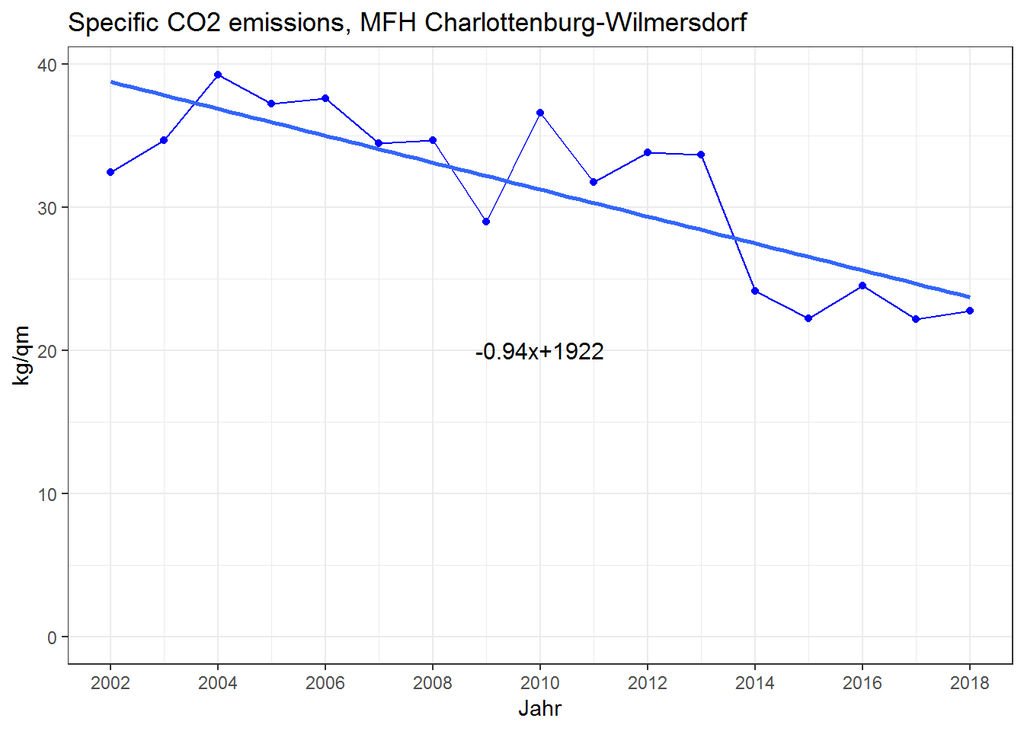

```r
points_line_lm(input_data = bezirk_spzco2_mfh,
               xVar = "abrechnungsjahr",
               yVar = "spzco2",
               ymin=0,
               ymax=max(bezirk_spzco2_mfh$spzco2),
               x_eq = 2010,
               y_eq = 20,
               size_eq = 4,
               plot_title = paste0("Specific CO2 emissions, MFH ",bezirk_proper_name),
               xlab = "Jahr",
               ylab = "kg/qm")
```

Isn’t it strange that the above graph has almost exactly the same shape as total co2 emissions?

```r
i_subsubsection <- i_subsubsection + 1
```

### 9.2.2. MFH, flächenbezogene CO2-Emssion und beheizte Wohnfläche 2002 – 2018

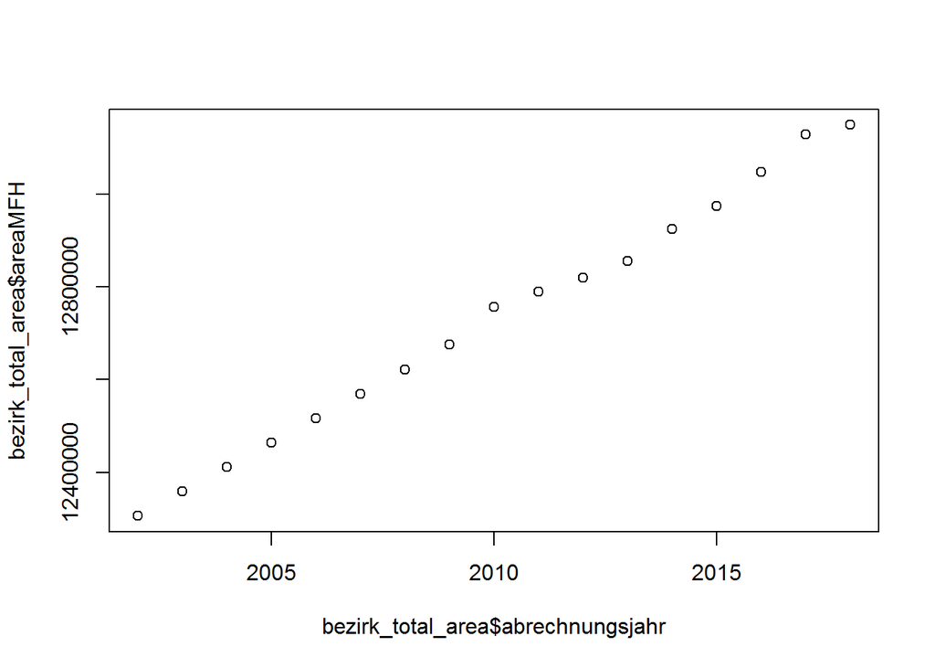

```r
plot(bezirk_total_area$abrechnungsjahr , bezirk_total_area$areaMFH)
```

```r
i_subsection <- i_subsection + 1
i_subsubsection <- 0
```

## 9.3. Emission pro Einwohner

```r
i_subsubsection <- i_subsubsection + 1
```

### 9.3.1. MFH, CO2-Emission aus der Beheizung von Wohnraum pro Einwohner 2002 - 2018

- Need data for this.

```r
i_subsection <- i_subsection + 1
i_subsubsection <- 0
```

## 9.4. Prognose

```r
i_subsubsection <- i_subsubsection + 1
```

### 9.4.1. Prognose der CO2-Emission aus Behei¬zung von Mehrfamiliengebäuden 2019 - 2030 in Mio. t (Trend Polynom 2. Grades)

```r
i_subsection <- i_subsection + 1
i_subsubsection <- 0
```

## 9.5. Einflussfaktoren

```r
i_subsubsection <- i_subsubsection + 1
```

### 9.5.1. MFH, Einfluss der Änderung der beheizten Flächen, des flächenbezogenen Heizenergieverbrauchs, des Energieträgerwechsels und der Dekarbonisierung auf die CO2-Emission

```r
i_subsubsection <- i_subsubsection + 1
```

### 9.5.2. MFH, Veränderung der flächenbezogenen CO2-Emission aus Beheizung zwischen 2012 und 2018

```r
i_subsubsection <- i_subsubsection + 1
```

### 9.5.3. MFH, Emissionsintensität der Beheizung von Wohnraum 2002 – 2018 in kg CO2 - Emission je kWh Heizenergieverbrauch

```r
i_subsubsection <- i_subsubsection + 1
```

### 9.5.4. MFH, CO2-Emission neu errichteter Gebäude, Vergleich der Baujahre 1990 – 2001 (WSchV) und 2002 – 2018 (EnEV)

```r
i_section <- i_section + 1
i_subsection <- 0
i_subsubsection <- 0
```

# 10.Charlottenburg-Wilmersdorf alle Wohngebäude, Heizenergieverbrauch 2002 – 2018

```r
i_subsection <- i_subsection + 1
```

## 10.1. alle Wohngebäude, Heizenergieverbrauch 2002 - 2018 in TWh

```r
return_aes <- extract_aes(return_SFH , return_MFH)
bezirk_aes_all <- return_aes$ALL
by_ten_9 <- 1e-9
bezirk_aes_all_TWh <- by_ten_9 * bezirk_aes_all
bezirk_aes_all_TWh$abrechnungsjahr <- 2002:2018
```

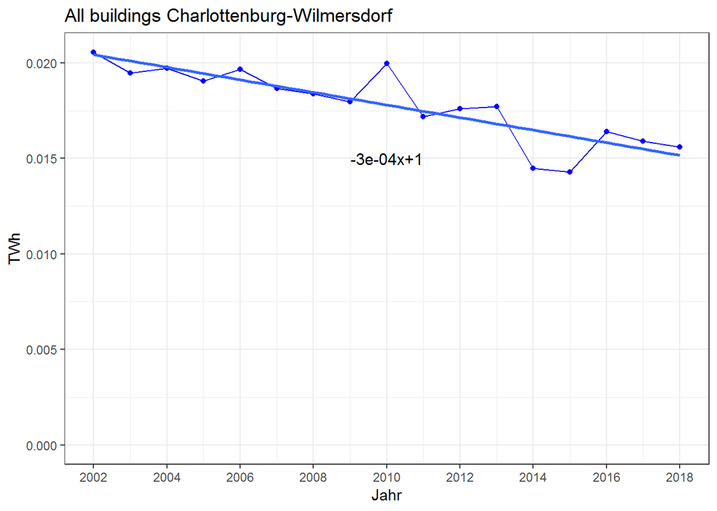

```r
points_line_lm(input_data = bezirk_aes_all_TWh,
               xVar = "abrechnungsjahr",
               yVar = "total",
               ymin=0,
               ymax=max(bezirk_aes_all_TWh$total),
               x_eq = 2010,
               y_eq = 0.015,
               size_eq = 4,
               plot_title = paste0("All buildings ",bezirk_proper_name),
               xlab = "Jahr",
               ylab = "TWh",
               slope_round_to = 4)
```

```r
i_subsection <- i_subsection + 1
```

## 10.2. alle Wohngebäude, Heizenergieverbrauch 2002 - 2018 nach Energieträgern, Anteile in TWh

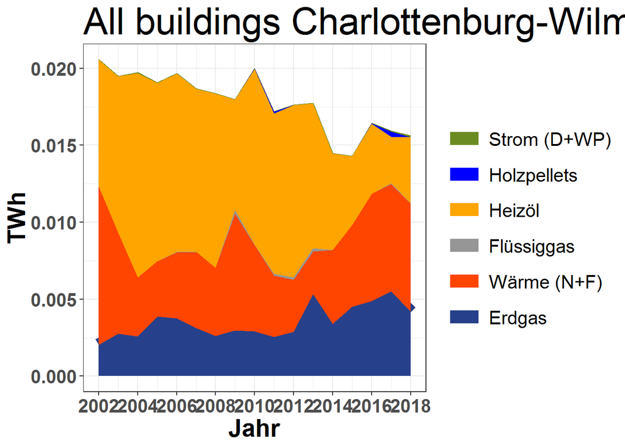

```r
bezirk_aes_all_TWh_cumsums <- getCumSums(bezirk_aes_all_TWh , dropCols = c("abrechnungsjahr","total"))
plot_byET(bezirk_aes_all_TWh_cumsums , xlabel = "Jahr" , ylabel = "TWh" , plottitle = paste0("All buildings ",bezirk_proper_name) )
```

```r
i_subsection <- i_subsection + 1
```

## 10.3. alle Wohngebäude, flächenbezogener Heizenergieverbrauch 2002 - 2018 in TWh

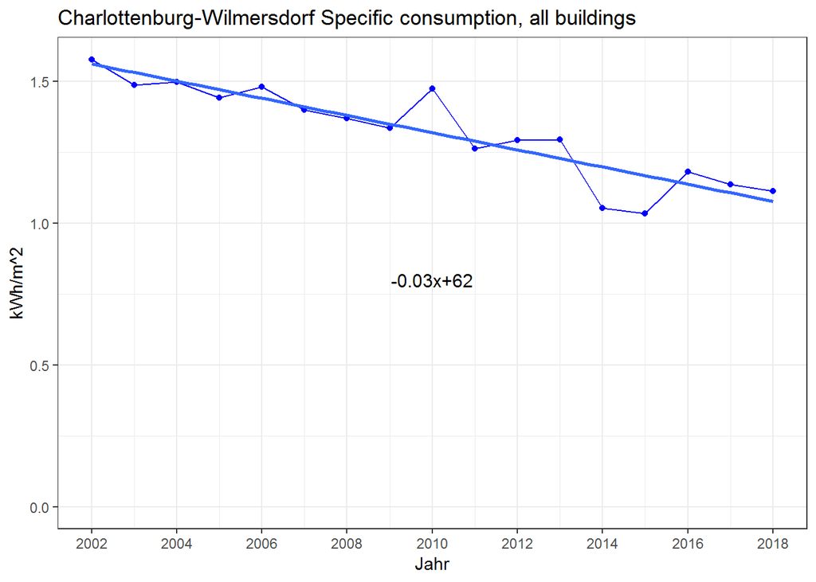

```r
bezirk_spz_verbrauch_all <- data.frame(abrechnungsjahr=2002:2018 ,   kWh_per_m2 =  bezirk_aes_all$total / bezirk_total_area$areaALL)

points_line_lm(input_data = bezirk_spz_verbrauch_all,
               xVar = "abrechnungsjahr",
               yVar = "kWh_per_m2",
               ymin = 0,
               ymax = max(bezirk_spz_verbrauch_all$kWh_per_m2),
               x_eq = 2010,
               y_eq = 0.8,
               size_eq = 4,
               plot_title = paste0(bezirk_proper_name, " Specific consumption, all buildings"),
               xlab = "Jahr",
               ylab = "kWh/m^2")
```

```r
i_subsection <- i_subsection + 1
```

## 10.4. alle Wohngebäude, flächenbezogener Heizenergieverbrauch nach Energieträgern 2002 - 2018 in TWh - **Should this not be TWh/m2** ?

```r
#return_SFH$area_prop_table
#multiply above with total areas to get areas heated by the respective ET
#divide absolute energy share of that ET with above to get the specific energy consumption of that ET
#bezirk_total_area contains the area
#return_aes$ALL contains the energy consumption, which is the same as bezirk_aes_all (in kWh) or bezirk_aes_all_TWh (in TWh).
```

The following gives area proportions for SFH buildings

```r
return_SFH$area_prop_table
```

```
##      erdgas    waerme fluessiggas  heizoel holzpellets    strom
## 1  12.55007  0.000000   0.0000000 87.44993    0.000000 0.000000
## 2  35.04651  0.000000   0.0000000 64.95349    0.000000 0.000000
## 3  22.58372  0.000000   0.0000000 77.41628    0.000000 0.000000
## 4  36.30571  5.007965   0.0000000 58.68633    0.000000 0.000000
## 5  25.48030  2.404789   0.6273362 71.48757    0.000000 0.000000
## 6  26.14676  4.506234   0.5749173 68.77209    0.000000 0.000000
## 7  31.18410  0.000000   0.0000000 68.81590    0.000000 0.000000
## 8  42.79214  5.262899   0.7076167 51.23735    0.000000 0.000000
## 9  40.69293  6.649598   0.5689496 50.16831    1.920205 0.000000
## 10 53.54016  1.606748   0.0000000 44.85309    0.000000 0.000000
## 11 48.25980 10.015524   5.0077620 35.59016    0.000000 1.126746
## 12 46.37391 15.586147   0.0000000 38.03994    0.000000 0.000000
## 13 42.65620  5.957242   0.0000000 51.38655    0.000000 0.000000
## 14 48.25305  5.952548   0.0000000 45.79440    0.000000 0.000000
```

[output cut: 21 more lines]

The following gives area proportions for MFH buildings

```r
return_MFH$area_prop_table
```

```
##      erdgas   waerme fluessiggas  heizoel holzpellets    strom
## 1  10.01751 57.84675   0.0000000 32.13574   0.0000000 0.000000
## 2  14.77000 37.32187   0.0000000 47.90812   0.0000000 0.000000
## 3  12.97485 22.77432   0.0000000 64.25083   0.0000000 0.000000
## 4  20.55267 24.17898   0.0000000 55.26835   0.0000000 0.000000
## 5  17.87623 31.19938   0.9573568 49.96703   0.0000000 0.000000
## 6  16.54352 36.57709   0.0000000 46.87939   0.0000000 0.000000
## 7  15.89823 31.23629   0.0000000 52.86548   0.0000000 0.000000
## 8  13.47652 54.11499   2.1396499 30.26885   0.0000000 0.000000
## 9  13.03957 35.07860   0.0000000 51.88183   0.0000000 0.000000
## 10 12.37517 26.43376   1.1417528 59.22683   0.8224949 0.000000
## 11 16.71806 23.06977   1.1916743 59.02049   0.0000000 0.000000
## 12 28.55751 20.07251   2.1297338 49.24025   0.0000000 0.000000
## 13 27.28466 33.29261   0.0000000 39.42273   0.0000000 0.000000
## 14 29.45054 46.89309   0.0000000 23.65637   0.0000000 0.000000
```

[output cut: 21 more lines]

Use the `areaSFH` column from the below data and multiply it with `return_SFH$area_prop_table` to get absolute area shares for SFH.

```r
bezirk_total_area
```

```
##    abrechnungsjahr  areaSFH  areaMFH  areaALL
## 1             2002 724536.9 12306348 13030885
## 2             2003 733050.0 12359000 13092050
## 3             2004 741563.1 12411652 13153215
## 41            2005 750076.2 12464305 13214381
## 5             2006 758589.3 12516957 13275546
## 6             2007 767102.4 12569610 13336712
## 7             2008 775615.5 12622262 13397877
## 8             2009 784128.6 12674914 13459043
## 4             2010 789600.0 12756700 13546300
## 16            2011 800500.0 12788900 13589400
## 28            2012 807600.0 12819500 13627100
## 40            2013 820500.0 12856100 13676600
## 52            2014 833900.0 12924500 13758400
## 64            2015 838800.0 12973400 13812200
## 76            2016 841200.0 13047900 13889100
## 88            2017 847400.0 13127800 13975200
## 9             2018 860746.4 13148786 14009532
```

The following gives the area warmed by each ET for SFH buildings:

```r
areas_SFH_byET <- 0.01*bezirk_total_area$areaSFH * return_SFH$area_prop_table
areas_SFH_byET$abrechnungsjahr <- 2002:2018
areas_SFH_byET <- getRowSums(areas_SFH_byET , dropCols = "abrechnungsjahr")
```

The following gives the area warmed by each ET for MFH buildings:

```r
areas_MFH_byET <- 0.01*bezirk_total_area$areaMFH * return_MFH$area_prop_table
areas_MFH_byET$abrechnungsjahr <- 2002:2018
areas_MFH_byET <- getRowSums(areas_MFH_byET , dropCols = "abrechnungsjahr")
```

Now you have to add `areas_MFH_byET` and `areas_MFH_byET` to get areas of ALL buildings.

```r
areas_ALL_byET <- areas_SFH_byET + areas_MFH_byET
areas_ALL_byET$abrechnungsjahr <- 2002:2018
```

The following gives the area warmed by each ET for ALL buildings:

```r
areas_ALL_byET
```

```
##     erdgas  waerme fluessiggas heizoel holzpellets      strom
## 1  1323719 7118823       0.000 4588343        0.00      0.000
## 2  2082333 4612610       0.000 6397107        0.00      0.000
## 3  1777866 2826669       0.000 8548680        0.00      0.000
## 4  2834068 3051306       0.000 7329008        0.00      0.000
## 5  2430851 3923455  124590.844 6796649        0.00      0.000
## 6  2280029 4632164    4410.204 6420109        0.00      0.000
## 7  2248585 3942726       0.000 7206566        0.00      0.000
## 8  2043682 6900296  276747.412 4238317        0.00      0.000
## 9  1984730 4527377    4492.426 7014538    15161.94      0.000
## 10 2011237 3393449  146017.618 7933509   105188.05      0.000
## 11 2532918 3038315  193209.376 7853558        0.00   9099.604
## 12 4051880 2708426  273800.702 6642494        0.00      0.000
## 13 3882116 4352581       0.000 5523704        0.00      0.000
## 14 4225483 6133558       0.000 3453159        0.00      0.000
```

[output cut: 21 more lines]

```r
#better to replace zero values by avg.
```

The following gives the absolute energy shares in kWh for each ET for all buildings:

```r
bezirk_aes_all #energies in kWh
```

```
##     erdgas   waerme fluessiggas  heizoel holzpellets     strom
## 1  2019671 10306972       0.000  8232040       0.000 10621.836
## 2  2744240  6549057       0.000 10175045       0.000 10621.836
## 3  2571305  3841424       0.000 13288833       0.000 10621.836
## 4  3867178  3585422       0.000 11590471       0.000 10621.836
## 5  3764162  4259492   43401.256 11594436       0.000 10621.836
## 6  3116876  4956448    8323.505 10572565       0.000 10621.836
## 7  2609148  4419129       0.000 11331732       0.000 10621.836
## 8  2960082  7586562  251622.991  7170222       0.000 10621.836
## 9  2911266  5624333    2789.941 11435678    4926.786     0.000
## 10 2548314  3967898  122275.597 10437725   97433.627     0.000
## 11 2870049  3383853  157978.885 11181943       0.000 15650.014
## 12 5331029  2759003  217771.387  9413751       0.000     0.000
## 13 3401584  4798056       0.000  6282042       0.000     0.000
## 14 4499382  5321592       0.000  4456706       0.000     0.000
```

[output cut: 21 more lines]

```r
#better to replace zero values by avg.
```

Now you have to divide `bezirk_aes_all` by `areas_ALL_byET` to get the specific consumption for ALL buildings and each ET. The following code does this:

```r
spz_vrbrch_all_byET <- bezirk_aes_all / areas_ALL_byET
spz_vrbrch_all_byET$abrechnungsjahr <- 2002:2018
spz_vrbrch_all_byET
```

```
##       erdgas    waerme fluessiggas  heizoel holzpellets     strom
## 1  1.5257548 1.4478478         NaN 1.794121         NaN       Inf
## 2  1.3178679 1.4198158         NaN 1.590570         NaN       Inf
## 3  1.4462871 1.3589931         NaN 1.554489         NaN       Inf
## 4  1.3645328 1.1750450         NaN 1.581452         NaN       Inf
## 5  1.5484952 1.0856482   0.3483503 1.705905         NaN       Inf
## 6  1.3670334 1.0700069   1.8873286 1.646789         NaN       Inf
## 7  1.1603509 1.1208309         NaN 1.572418         NaN       Inf
## 8  1.4484059 1.0994546   0.9092153 1.691762         NaN       Inf
## 9  1.4668323 1.2422937   0.6210321 1.630282   0.3249444       NaN
## 10 1.2670384 1.1692818   0.8374030 1.315651   0.9262804       NaN
## 11 1.1330999 1.1137270   0.8176564 1.423806         NaN 1.7198565
## 12 1.3156927 1.0186741   0.7953646 1.417201         NaN       NaN
## 13 0.8762192 1.1023475         NaN 1.137288         NaN       NaN
## 14 1.0648209 0.8676191         NaN 1.290617         NaN       NaN
```

[output cut: 21 more lines]

Write a function to achieve the above. Needs as input: `bezirk_aes_all`, `bezirk_aes_sfh` (not yet calculated) and `bezirk_aes_mfh` (not yet calculated); areas_ALL_byET - this requires `areas_SFH_byET` and `areas_MFH_byET` - these require `bezirk_total_area$areaMFH`, `bezirk_total_area$areaSFH`, `return_MFH$area_prop_table` and `return_SFH$area_prop_table`.

```r
replaceZeroByMean <- function(obj,dropCols) {
  vars <- names(obj)[!(names(obj) %in% dropCols)]
  for (var in vars) {
    isZero <- obj[[var]] == 0
    obj[[var]][isZero] <- mean(obj[[var]][!isZero])
  }
  return(obj)
}

getSpzVrbrchByET <- function(gtype,bezirk_aes,bezirk_total_area,area_prop_table_SFH,area_prop_table_MFH) {
  # gtype is "ALL", "SFH", or "MFH".
  # bezirk_aes is bezirk_aes_all, or bezirk_aes_sfh or bezirk_aes_mfh.
  # bezirk_total_area is bezirk_total_area.
  # area_prop_table_SFH is return_SFH$area_prop_table
  # area_prop_table_MFH is return_MFH$area_prop_table
  #
  # replace zero values by avg in bezirk_aes
  bezirk_aes <- replaceZeroByMean(bezirk_aes,"abrechnungsjahr")

  areas_SFH_byET <- 0.01*bezirk_total_area$areaSFH * area_prop_table_SFH
  areas_SFH_byET$abrechnungsjahr <- 2002:2018
  areas_SFH_byET <- getRowSums(areas_SFH_byET , dropCols = "abrechnungsjahr")

  areas_MFH_byET <- 0.01*bezirk_total_area$areaMFH * area_prop_table_MFH
  areas_MFH_byET$abrechnungsjahr <- 2002:2018
  areas_MFH_byET <- getRowSums(areas_MFH_byET , dropCols = "abrechnungsjahr")

  if (gtype=="ALL") {

    areas_ALL_byET <- areas_SFH_byET + areas_MFH_byET
    areas_ALL_byET$abrechnungsjahr <- 2002:2018

    # replace zero values by avg in areas_ALL_byET
    areas_ALL_byET <- replaceZeroByMean(areas_ALL_byET , "abrechnungsjahr")

    spz_vrbrch_all_byET <- bezirk_aes / areas_ALL_byET
    spz_vrbrch_all_byET$abrechnungsjahr <- 2002:2018
    return_data <- spz_vrbrch_all_byET
  }

  if (gtype=="SFH") {
    # replace zero values by avg in areas_SFH_byET
    areas_SFH_byET <- replaceZeroByMean(areas_SFH_byET , "abrechnungsjahr")
    spz_vrbrch_sfh_byET <- bezirk_aes / areas_SFH_byET
    spz_vrbrch_sfh_byET$abrechnungsjahr <- 2002:2018
    return_data <- spz_vrbrch_sfh_byET
  }

  if (gtype=="MFH") {
    # replace zero values by avg in areas_MFH_byET
    areas_MFH_byET <- replaceZeroByMean(areas_MFH_byET , "abrechnungsjahr")
    spz_vrbrch_mfh_byET <- bezirk_aes / areas_MFH_byET
    spz_vrbrch_mfh_byET$abrechnungsjahr <- 2002:2018
    return_data <- spz_vrbrch_mfh_byET
  }
  return(return_data)
}
```

```r
getSpzVrbrchByET("ALL",
                 bezirk_aes_all,
                 bezirk_total_area,
                 return_SFH$area_prop_table,
                 return_MFH$area_prop_table)
```

```
##       erdgas    waerme fluessiggas  heizoel holzpellets     strom
## 1  1.5257548 1.4478478   0.8128706 1.794121   1.3873824 0.1204848
## 2  1.3178679 1.4198158   0.8128706 1.590570   1.3873824 0.1204848
## 3  1.4462871 1.3589931   0.8128706 1.554489   1.3873824 0.1204848
## 4  1.3645328 1.1750450   0.8128706 1.581452   1.3873824 0.1204848
## 5  1.5484952 1.0856482   0.3483503 1.705905   1.3873824 0.1204848
## 6  1.3670334 1.0700069   1.8873286 1.646789   1.3873824 0.1204848
## 7  1.1603509 1.1208309   0.8128706 1.572418   1.3873824 0.1204848
## 8  1.4484059 1.0994546   0.9092153 1.691762   1.3873824 0.1204848
## 9  1.4668323 1.2422937   0.6210321 1.630282   0.3249444 0.1862037
## 10 1.2670384 1.1692818   0.8374030 1.315651   0.9262804 0.1862037
## 11 1.1330999 1.1137270   0.8176564 1.423806   1.3873824 1.7198565
## 12 1.3156927 1.0186741   0.7953646 1.417201   1.3873824 0.1862037
## 13 0.8762192 1.1023475   0.8128706 1.137288   1.3873824 0.1862037
## 14 1.0648209 0.8676191   0.8128706 1.290617   1.3873824 0.1862037
```

[output cut: 21 more lines]

```r
i_subsection <- i_subsection + 1
```

## 10.5. alle Wohngebäude, Heizenergieverbrauch 2002 - 2018 nach Energieträgern, Anteile in %

```r
i_subsection <- i_subsection + 1
```

## 10.6. alle Wohngebäude, flächenbezogener Heizenergieverbrauch und beheizte Wohnfläche 2002 – 2018

```r
i_subsection <- i_subsection + 1
```

## 10.7. alle Wohngebäude, flächenbezogener Heizenergieverbrauch neu errichteter Gebäude, Vergleich der Baujahre 1990 – 2001 (WSchV) und 2002 – 2018 (EnEV)